# Variação morfológica de quatro espécies de Serpentes do Gênero *Helicops* (Wagler, 1830)

Albedi Andrade Junior

25/03/2020

## **Introdução**

O gênero *Helicops* descrito por Wagler 1830 (Serpentes: Dipsadidae: Xenodontinae) é composto por 17 espécies de serpentes de hábitos aquáticos (Costa et al., 2016), amplamente distribuídos na América do Sul com ocorrência fortemente associada às bacias hidrográficas do continente (Albuquerque, 2002; Yuki and Lema, 2005; Ávila et al., 2006). O gênero *Helicops* se diferencia do demais hydropsínios pela ornamentação hemipeniana diferenciada, diagnosticada pela presença de franjas nuas nos lobos do hemipênis (Zaher, 1999). No tocante a morfologia externa, o gênero *Helicops* se diferencia plenamente de *Pseudoeryx* e *Hydrops* pela presença de escamas dorsais quilhadas (Peters and Orejas-Miranda, 1970; Di Pietro et al., 2014; Costa et al., 2016). A morfologia hemipeniana representa a principal fonte de informações que dá identidade ao gênero como uma entidade à parte em Hydropsini.

### **Objetivo**

Investigar a presença de dimorfismo sexual em quatro espécies de *Helicops*.

## **Material e Métodos**

### Amostragem

Foram analisados 38 espécimes identificados como *SP1, SP2, SP3 e SP4* disponíveis ao longo de sua cobertura geográfica depositados em 3 coleções científicas nacionais: Museu Nacional do Rio de Janeiro (MNRJ), Coleção Herpetológica da Universidade Federal de Mato Grosso (CHUFMT) Coelão Herpetológica da Pontifícia Universidade Católica de Goiás (CHPUCGO).

A determinação do sexo dos exemplares foi feita com base na presença ou ausência do órgão copulador masculino, hemipênis. Uma incisão longitudinal na cauda, entre as placas subcaudais 5 a 10, para verificação direta quando o órgão não era visível externamente.

**Caracteres quantitativos**

- Número de escamas ventrais (Vent);
- Número de escamas subcaudais (Sub).

**Caracteres quantitativos morfométricos**

- Comprimento rostro-cloacal (CRC);
- Comprimento da cauda (CC);
- Comprimento total (Ctot).

## **Resultados**

As especies estão distribuidas desde a Amazônia meridional nas sub-bacias do Amazônas e áreas abertas da diagonal sulamericana nas sub-bacias do Prata (Fig 4).

- ```
           Df Sum Sq Mean Sq F value Pr(>F)
  ```

- Comprimento Total 1 50 49.7 0.128 **0.723**
- Residuals 35 13567 387.6
- Nº Escamas Ventrais 1 265 265.4 0.865 **0.359**
- Residuals 35 10739 306.8

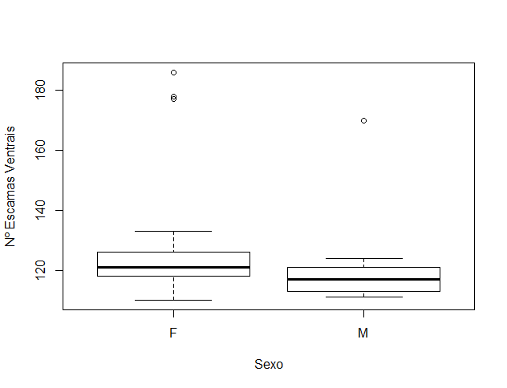

```r
knitr::include_graphics("../figs/Dimorfismo 1.png")
```

**Figura 1**: Dimorfismo sexual com base no número de escamas ventrais.

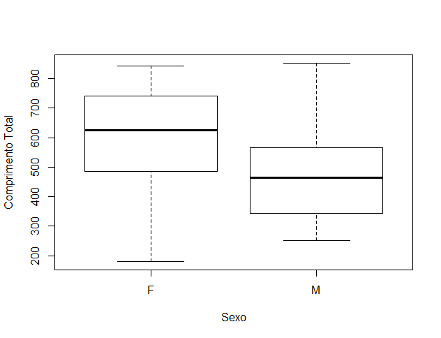

```r
knitr::include_graphics("../figs/Dimorfismo 2.png")
```

**Figura 2**: Dimorfismo sexual com base no Comprimento Total de Fêmeas e Machos das quatro espécies juntas.

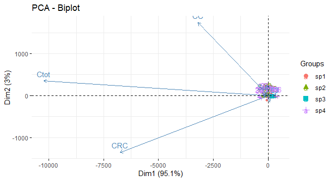

```r
knitr::include_graphics("../figs/PCA.png")
```

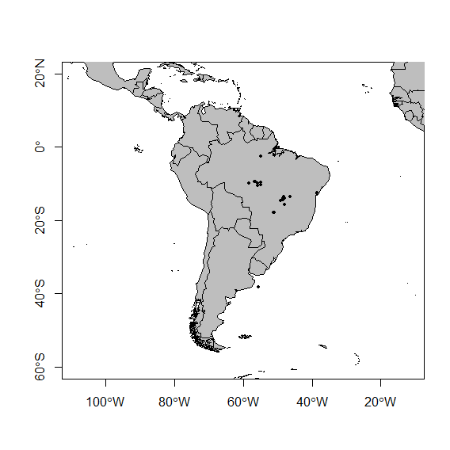

```r
knitr::include_graphics("../figs/Map_SPP.png")
```

**Figura 4**: Distribuição geográfica das espécies de *Helicops*.

## Referências

Albuquerque, N. R., 2002. Osteologia craniana, morfologia do hemipênis e o posicionamento sistemático do gênero Hydrops Wagler, 1830 (Serpentes: Colubridae). Comunicações do Museu Ciências e Tecnologia PUCRS, Série Zoologia 15: 41-54.

Ávila, R.W., V.L. Ferreira, e J.A.O. Arruda. 2006. Natural history of the South American water snake Helicops leopardinus (Colubridae: Hydropsini) in the Pantanal, Central Brasil. Journal of Herpetology40: 274-279.

Costa, H.C., Santana, D.J., Leal, F., Koroiva, R. & Garcia, P.C.A. (2016) A New Species of Helicops (Serpentes: Dipsadidae: Hydropsini) from Southeastern Brazil. Herpetologica, 72, 157–166. https://doi.org/10.1655/HERPETOLOGICA-D-15-00059

Di Pietro, D. O., Alcalde, L. e Williams, J. D. 2014. New cranial characters in the tribe Hydropsini (Serpentes: Dipsadidae: Xenodontinae). Acta Herpetologica9: 1-14.

Peters, J. A. & B. Orejas-Miranda, 1970. Catalogue of the Neotropical Squamata. ParteI: Snakes. United States National Museum Bulletin. 297:1–347.

Yuki, R.N., and T. Lema. 2005. Análise comparativa entre as cobras d’água meridionais Helicops carinicaudus (wied, 1825) e Helicops infrataeniatus Jan, 1865), com a descrição do crânio e hemipênis (Serpentes: Colubridae: Xenodontinae). Comunicações do Museu de Ciência e Tecnologia da PUCRS, Série Zoologia 18:85–128.

Zaher, H., F. G. Grazziotin, J. E. Cadle, R. W. Murphy, J. C. Moura-Leite & S. L. Bonatto. 2009. Molecular phylogeny of advanced snakes (Serpentes, Caenophidia) with emphasis on South American Xenodontines: a revised classification and descriptions of new taxa. Papéis Avulsos de Zoologia. 49: 115–153.